# AM_Sep7_TimeBudgetIndoor

Keni Ren

2023-09-07

## Structure of the code

- Example code: ‘AM_Sep7_TimeBudgetIndoor.rmd’
- ‘TimeBudget_Functions/data.R’:Functions to read, clean and manipulate data
- ‘TimeBudget_Functions/plot.R’:Functions to plot data
- ‘TimeBudget_Functions/analysis.R’: Methods to process and analyse data

## Activity data and trajectory

Here, we read in the barn’s blueprint from .csv file, add function areas and bed number to the barn’s blue print.Please check more in plot.R.

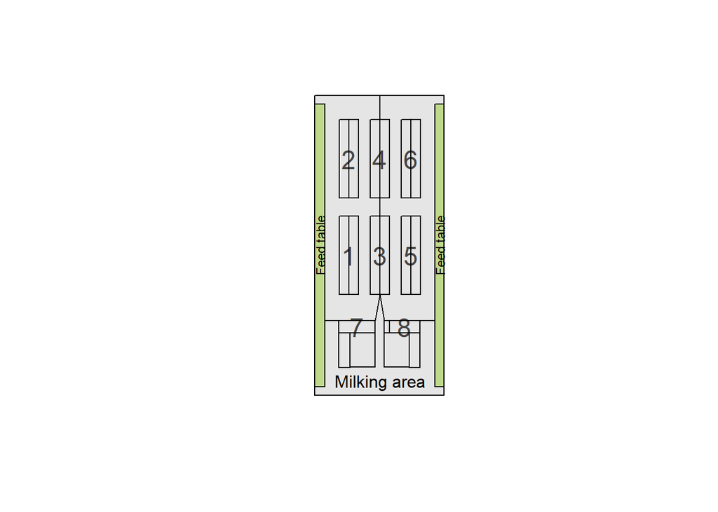

```r
barn<-readBarnData(paste0(dataFolder, "/BarnMap.csv"))
plotBarn(barn, bRotated = FALSE, axes = FALSE)
addBarnFeatures(barn)
```

Read in PA data, plot one individual’s activity data and trajectory. Please read more in data.R.

```r
PAdata <- read.PAData(paste0(dataFolder,"/PA_20201017T000000UTC.csv"))
```

```
## [1] "Read in 0.426423072814941 seconds"
```

```r
head(PAdata,8) #show first 8 rows of the data
```

```
## # A tibble: 8 × 10
##   FileType      id tag               t1      t2     x     y     z activity  dist
##   <chr>      <dbl> <chr>          <dbl>   <dbl> <dbl> <dbl> <dbl>    <dbl> <dbl>
## 1 PA       2433150 0025207E     1.60e12 1.60e12  2596  7000   198        3     0
## 2 PA       2428893 00250FDD     1.60e12 1.60e12   788  8192   198        2     3
## 3 PA       2432087 00251C57     1.60e12 1.60e12  3014  1620   198        2    42
## 4 PA       2428796 00250F7C     1.60e12 1.60e12   624  2716   198        2    77
## 5 PA       2428893 00250FDD     1.60e12 1.60e12   788  8192   198        1     0
## 6 PA       2428906 00250FEA     1.60e12 1.60e12  2960  2817     0        2    26
## 7 PA       2428898 00250FE2     1.60e12 1.60e12  3069  1664   198        2     8
## 8 PA       2432087 00251C57     1.60e12 1.60e12  3014  1620   198        1     0
```

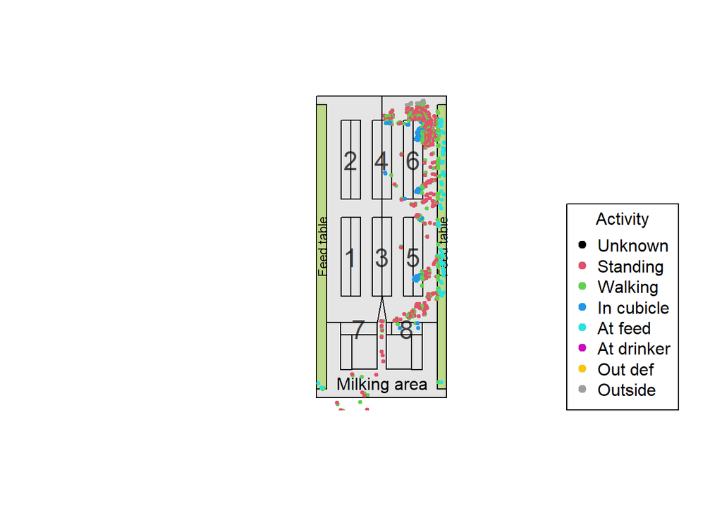

```r
# Plot one individual's activity data
#pdf(paste0(outputFolder, "/PA.pdf"), width = 11, height = 6) #if you want to print it in PDF

id<-2421861

data <- PAdata[which(PAdata$id == id), ]
plotBarn(barn, bRotated = FALSE, axes = FALSE)
addBarnFeatures(barn)

points(data$x, data$y, pch = 19, col = data$activity + 1, cex = 0.5)


legend("bottomright", legend = c("Unknown", "Standing", "Walking", "In cubicle",
                                 "At feed", "At drinker", "Out def", "Outside"),
       title = "Activity", col = c(0, 1, 2, 3, 4, 5, 998, 999) + 1, pch = 19, bg = NA)
```

```r
#dev.off() #if you want to print it in PDF
```

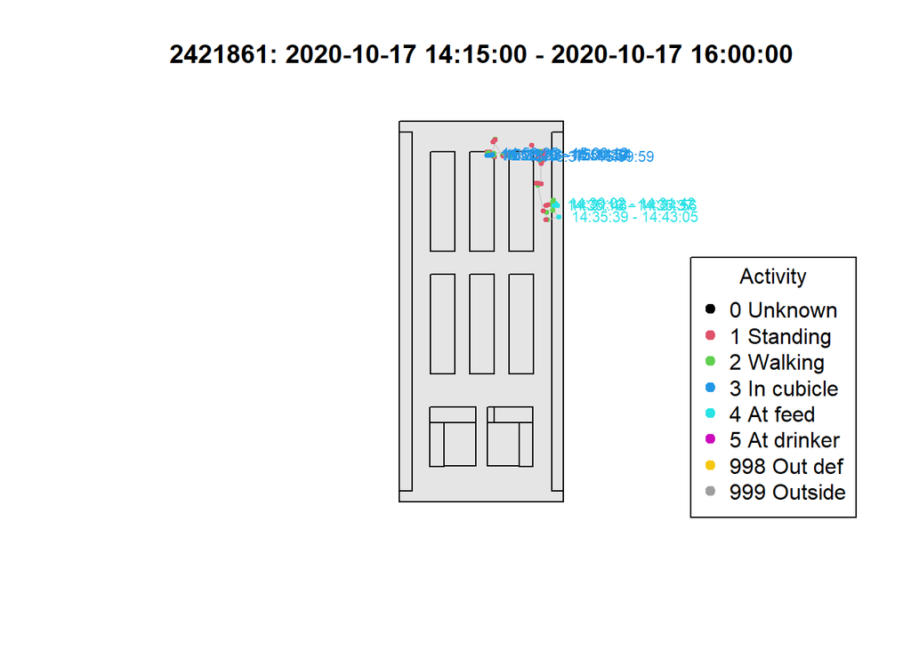

```
## [1] "4: 14:30:02 - 14:31:42"
## [1] "2: 14:31:42 - 14:31:48"
## [1] "4: 14:31:48 - 14:34:56"
## [1] "2: 14:34:56 - 14:35:02"
## [1] "1: 14:35:02 - 14:35:03"
## [1] "2: 14:35:03 - 14:35:05"
## [1] "1: 14:35:05 - 14:35:06"
## [1] "2: 14:35:06 - 14:35:16"
## [1] "4: 14:35:16 - 14:35:37"
## [1] "2: 14:35:37 - 14:35:39"
## [1] "4: 14:35:39 - 14:43:05"
## [1] "2: 14:43:05 - 14:43:10"
## [1] "1: 14:43:10 - 14:43:18"
## [1] "2: 14:43:18 - 14:43:26"
## [1] "1: 14:43:26 - 14:44:04"
```

[output cut: 69 more lines]

```r
# Create PDF, plot one individual's trajcatory during specific time.

#pdf(paste0(outputFolder, "/traj.pdf"), width = 11, height = 6) #if you want to print it in PDF
plotPATrajectory(PAdata, id,
                 startTime = as.POSIXct("2020-10-17 14:15:00 CET"),
                 endTime = as.POSIXct("2020-10-17 16:00:00 CET"))
```

```r
#dev.off()  #if you want to print it in PDF
```

## Daily time budget

We could select a group of cows and calculate their daily time budget.We define the time budget here as the the proportion of the daily activity that was spent in the Alley standing (1), Alley walking (2), cubicles (3) and feeding (4) area. Please check more in analysis.R.

```r
#Select a group of cows
CPheno <- read.table(paste0(dataFolder,"/Cow_Phenotypes.csv"), header = TRUE, sep = ",")
Select <- CPheno[which(CPheno$Lactation_stage == "Early"&CPheno$Parity == "2"), ]
SelectTags <- Select$Tag
print(paste("Number of individuals: ", length(SelectTags)) )
```

```
## [1] "Number of individuals:  5"
```

```r
print(SelectTags )
```

```
## [1] "00250AAC" "00250ACA" "00250ADC" "00250BFA" "00250FD5"
```

```r
#Timebudget
TBS=getTimeBudget(PAdata, selectedIDs=SelectTags)
print(TBS)
```

```
##        tag          Standing           Walking              Rest
## 1 00250AAC 0.149463641054715 0.186245942938688 0.404871258297572
## 2 00250ACA 0.132555198857926  0.17548815059856 0.474272955816562
## 3 00250ADC 0.192084740856872 0.246008505835696 0.347851693847693
## 4 00250BFA 0.155013295374064 0.183861972369066 0.384300465546426
## 5 00250FD5 0.143685815375689  0.17430184239866 0.401060713257606
##             Feeding
## 1  0.25901076639188
## 2  0.21712214364504
## 3 0.213691691303248
## 4 0.276824266710444
## 5 0.277373236770344
```

## Cubicle preference

Modern dairy cattle farms are usually equipped with cubicle systems to provide cows with comfortable conditions for lying down and resting. Cows are free to choose any cubicle they want, but in reality, they do not distribute themselves uniformly throughout the barn. There are many factors that affect where a cow lies down, such as hierarchy of a cow, access to resources, cow traffic nearby, etc. We could use real-time location system data to examine patterns of cubicle occupancy in relation to parity and lactation stage. Please check more in analysis.R.

Further read: [Churakov, Mikhail, et al. “Parity and days in milk affect cubicle occupancy in dairy cows.” Applied Animal Behaviour Science 244 (2021): 105494.](https://www.sciencedirect.com/science/article/pii/S0168159121002811)

```
## bed1... bed2... bed3... bed4... bed5... bed6... Done!
```

[figure not shown]

```r
#Cubic usage heatmap

#pdf(paste0(outputFolder, "/CubicUsage.pdf"), width = 11, height = 6) #if you want to print it in PDF
CubicUsage=getDailyCubicleUsageHeatmap(PAdata,SelectTags,barn)
```

```r
#dev.off()  #if you want to print it in PDF
```